# Visualization of NGS Data using IGV (v2.4+) - Practical

Elodie GIRARD, Sarah GUINCHARD, Rachel LEGENDRE, Pierre PERICARD, Olivier QUENEZ, and the EBAII team

2022-11-07

# 1 Training data

Training data is available on : https://github.com/IFB-ElixirFr/EBAII/raw/master/2022/ebaiin1/IGV/data_igv.zip

# 2 Visualization of variants in DNAseq data

In this section we are going to visualize two types of DNA variants. First, we will look at single nucleotide variations (SNV) in an individual’s genome, and compare those SNVs with those present in the two parents’. Then, we are going to have a look at a copy number variation (CNV) type of genomic variant.

## 2.1 SNV

- In the top menu, select **“New session”**
- In the first drop-down menu, select the appropriate genome : **Human (GRCh37/hg19)**
- In the top menu, select **“Load from File”** then select the **“dnaseq.bam”** and the **“dnaseq_variant.bed”** files
- Zoom in the **“variant239”** region and observe the heterozygous SNV at the position chr12:11,461,470, indicated by colored bases

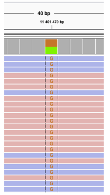

Point mutation

- Zoom in the **“variant230”** region and observe the 3bp-deletion at the position chr12:9,994,446, indicated by a blank space crossed by a black line

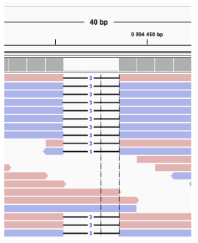

Deletion

- Zoom in the **“variant240”** region and observe the insertion at the position chr12:11,461,554 , indicated by a purple bar

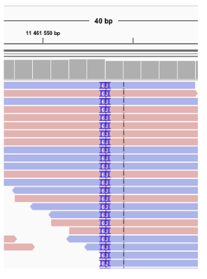

Insertion

- In the top menu, select **“New session”**
- In the top menu, select **“Load from File”** then select the **Trio_001.chr19_33493205.bam**, **Trio_002.chr19_33493205.bam** and **Trio_003.chr19_33493205.bam** files
- Zoom in the chr19:33,493,260-33,493,397 region and observe the two variants in the area, one inherited from the father (002) and the other from the mother (003)

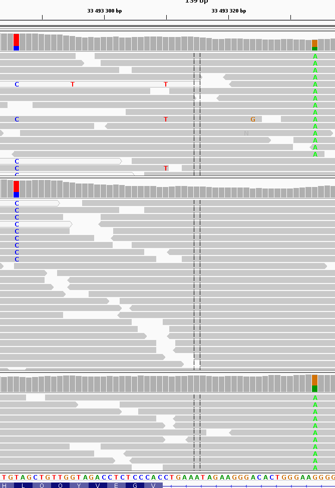

Multiple sample

- Tips:
  - Always **sort reads by base** at a variant position and **color them by strand**
  - Control the visualization parameters set in **“View > Preferences”**
  - Base counts indicated by hovering on the coverage track at the variant position can help assess the variant allelic ratio.  
    The decomposition on the forward/reverse strands can help determine a **potential strand bias**: when a base is covered by the same amount of forward and reverse alignments (blue and pink) and the variant is supported by a high proportion of one type of strand (ie: 90%), it might be an artifact.

## 2.2 CNV

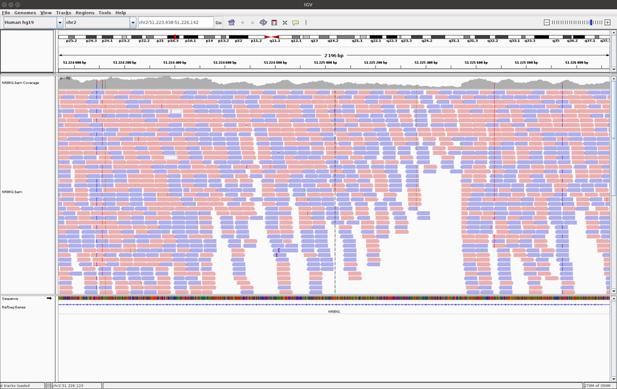

Deletion NRXN1

- Right click on the alignment track, select **“View as pairs”**
- Right click on the alignment track, select **“Color alignments by”** then **“insert size and pair orientation”**
- Right click on the alignment track, select **“Sort alignments by”** then **“insert size”**

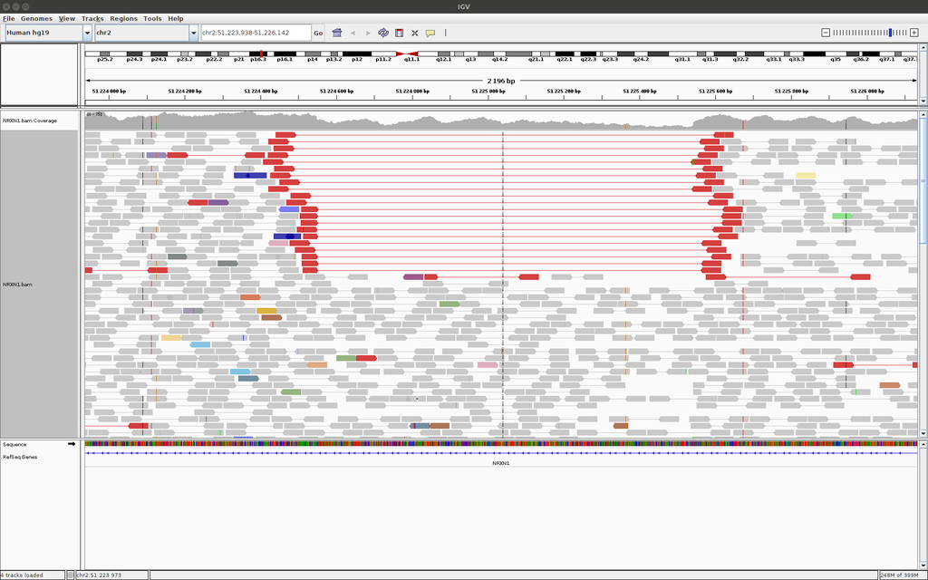

Deletion NRXN1

# 3 Visualization of an alternative isoform in RNA-seq data

A variant impacting the splicing site of the exon 6 of the *OAS1* gene (chr12:113,357,193 ; Pickrell et al, 2012) is producing an alternative isoform that contains the retention of a part of the following intron.

- In the top menu, select **“New session”**
- In the top menu, select **“Load from File”** then select the **“rnaseq.bam”** file
- Zoom in the *OAS1* region. If you see the **“Zoom in to see alignments”** message, zoom in until you see alignments.

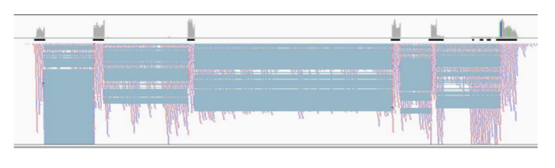

- Set the track in its **collapsed mode** by right clicking on the alignment track The blue lines link the different parts of a spanning read that, by definition, map on several exons. Zoom in on the two last exons of OAS1 then sort the alignments by base just before the last exon. You can see alignments outside of the known exons of this gene.

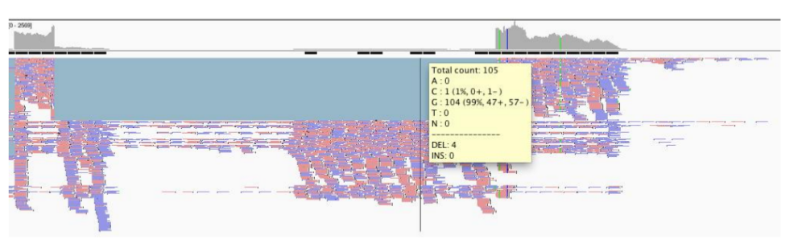

- **Right click** on the alignment track, select **“sashimi-plot”**. You’ll see the exons coverage and junctions lines with a number specifying the number of spanning reads for this junction. Zoom in the last 2 exons, move the track and click on an exon to only see junctions involving this exon (click on an intron to see everything).

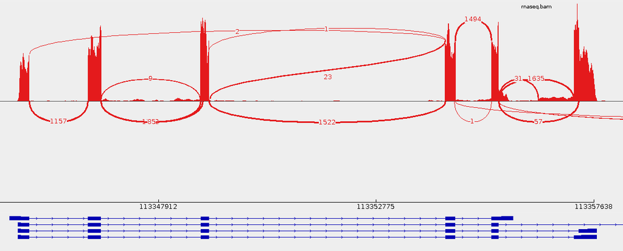

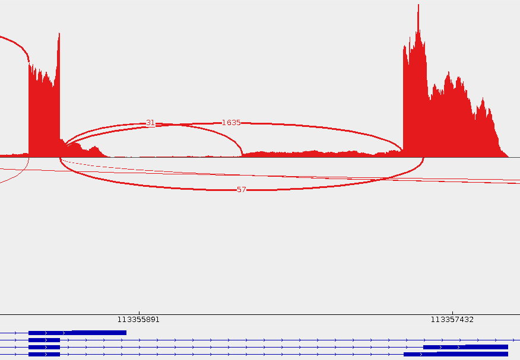

/!\ Sashimi plots are very useful to get a descriptive view of RNA-seq data but cannot replace a proper analysis : it’s only a visualization tool. /!\

# 4 Visualization of the Transcription Factor GATA-3 Binding Sites by ChIP-seq from ENCODE

ChIP-seq data from the ENCODE project are used in this part in order to observe at the same time a BAM file containing the reads alignments, the normalized signal in a BIGWIG file and a BED file containing the enriched regions of high read density (peaks) identified by the bioinformatics analysis.  
These peaks correspond to the predicted binding sites of the studied transcription factor, GATA-3 in the Mcf7 cell line.

These data can be access directly via IGV (or load the saved session **“chipseq.xml”**) :

- In the top menu, select **“New session”**
- In the top menu, select **“File”** then **“Load from ENCODE (2012)”**

[figure not shown]

- Write the following keywords: **“mcf-7 gata3 usc SC-268”** and select the following tracks then click on **“Load”**

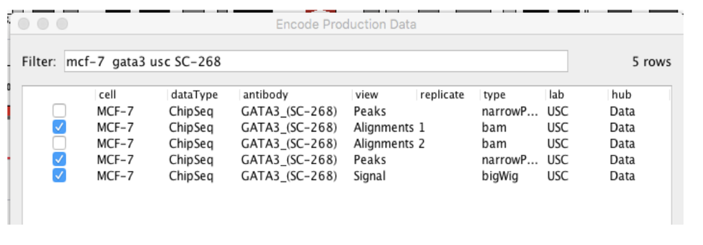

- Repeat the operation and write the following keywords to import the INPUT signal: **“mcf-7 input usc signal”** and select the following track then click on **“Load”**

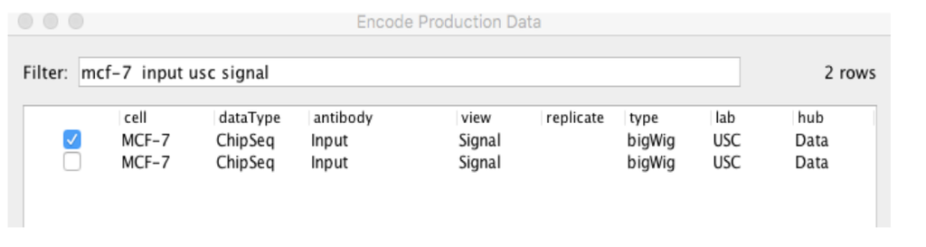

**Visualization of two peaks** :

- Zoom in this specific region : **chr2:190,349,562-190,354,046**
- Right click on the name of the **“MCF-7 GATA3”** IP Signal and click on **“Change Track Color…”** then select the color red
- Repeat the operation for the **“MCF-7 Input”** Signal and select the color light blue
- Select both Signal tracks by maintaining the **“ctrl”** key and clicking on the names then right-click on one of them and click on **“Group autoscale”** to adapt the scale of both tracks

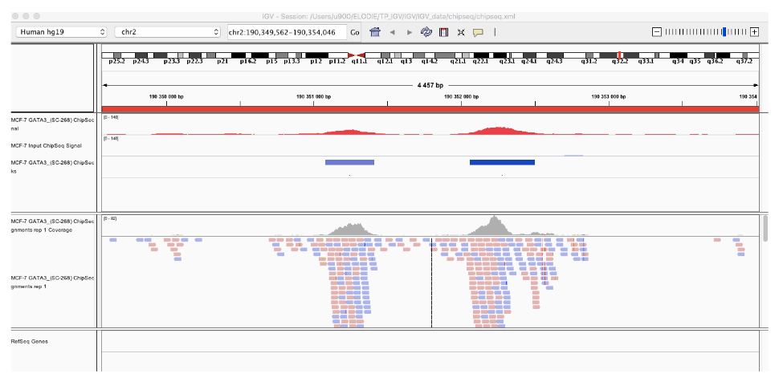

**Visualization of a region that is not enriched in the IP** :

- Remove the alignment track by right clicking on the name then select **“Remove track”**
- Zoom in this specific region : **chr20:55,741,582-55,790,445**
- Select both Signal tracks by maintaining the **“ctrl”** key and clicking on the names then right-click on one of them and click on **“Overlay tracks”** to display both signals on the same track

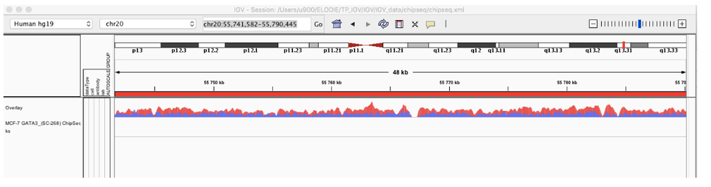